# XMM-LSS master catalogue

## Preparation of Hyper Suprime-Cam Subaru Strategic Program Catalogues (HSC-SSP) ultradeep data

In the catalogue, we keep:

- The `object_id` as unique object identifier;
- The position;
- The g, r, i, z, y, n921, n816 aperture magnitude in 2” that we aperture correct;
- The g, r, i, z, y, n921, n816 kron fluxes and magnitudes.
- The extended flag that we convert to a stellariy.

**TODO**: Check that the magnitudes are AB.

We don't know when the maps have been observed. We will use the year of the reference paper.

```python
from herschelhelp_internal import git_version
print("This notebook was run with herschelhelp_internal version: \n{}".format(git_version()))
```

```
This notebook was run with herschelhelp_internal version:
33f5ec7 (Wed Dec 6 16:56:17 2017 +0000)
```

```python
%matplotlib inline
#%config InlineBackend.figure_format = 'svg'

import matplotlib.pyplot as plt
plt.rc('figure', figsize=(10, 6))
plt.style.use('ggplot')

from collections import OrderedDict
import os

from astropy import units as u
from astropy import visualization as vis
from astropy.coordinates import SkyCoord
from astropy.table import Column, Table
import numpy as np

from herschelhelp_internal.flagging import  gaia_flag_column
from herschelhelp_internal.masterlist import nb_astcor_diag_plot, nb_plot_mag_ap_evol, \
    nb_plot_mag_vs_apcor, remove_duplicates
from herschelhelp_internal.utils import astrometric_correction, mag_to_flux, aperture_correction
```

```python
OUT_DIR =  os.environ.get('TMP_DIR', "./data_tmp")
try:
    os.makedirs(OUT_DIR)
except FileExistsError:
    pass

RA_COL = "hsc-udeep_ra"
DEC_COL = "hsc-udeep_dec"
```

```python
# Pritine HSC catalogue
orig_hsc = Table.read("../../dmu0/dmu0_HSC/data/HSC-PDR1_uDeep_XMM-LSS.fits")
```

## I - Aperture correction

To compute aperture correction we need to dertermine two parametres: the target aperture and the range of magnitudes for the stars that will be used to compute the correction.

**Target aperture**: To determine the target aperture, we simulate a curve of growth using the provided apertures and draw two figures:

- The evolution of the magnitudes of the objects by plotting on the same plot aperture number vs the mean magnitude.
- The mean gain (loss when negative) of magnitude is each aperture compared to the previous (except for the first of course).

As target aperture, we should use the smallest (i.e. less noisy) aperture for which most of the flux is captures.

**Magnitude range**: To know what limits in aperture to use when doing the aperture correction, we plot for each magnitude bin the correction that is computed and its RMS. We should then use the wide limits (to use more stars) where the correction is stable and with few dispersion.

```python
bands = ["g", "r", "i", "z", "y", "n921", "n816"]
apertures = ["10", "15", "20", "30", "40", "57", "84", "118", "168", "235"] #Removed "40" and "235" because they lack errors

magnitudes = {}
magnitude_errors ={}
stellarities = {}

for band in bands:
    magnitudes[band] = np.array(
        [orig_hsc["{}mag_aperture{}".format(band, aperture)] for aperture in apertures]
    )
    magnitude_errors[band] = np.array(
        [orig_hsc["{}mag_aperture{}_err".format(band, aperture)] for aperture in apertures]
    )
    stellarities[band] = 1 - np.array(orig_hsc["{}classification_extendedness".format(band)])

    # Some sources have an infinite magnitude
    mask = np.isinf(magnitudes[band])
    magnitudes[band][mask] = np.nan
    magnitude_errors[band][mask] = np.nan

mag_corr = {}
```

### I.a - g band

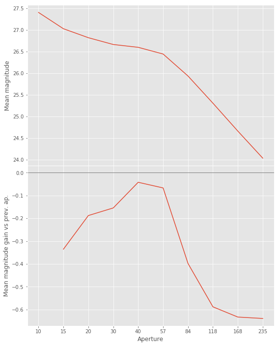

```python
nb_plot_mag_ap_evol(magnitudes['g'], stellarities['g'], labels=apertures)
```

We will use aperture 40 as target.

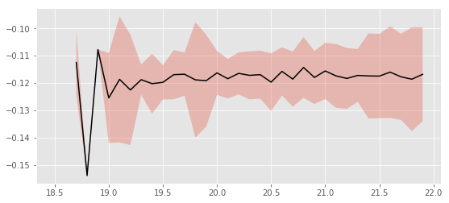

```python
nb_plot_mag_vs_apcor(orig_hsc['gmag_aperture20'], orig_hsc['gmag_aperture40'], stellarities['g'])
```

We will use magnitudes between 20.0 and 21.5

```python
# Aperture correction
mag_corr['g'], num, std = aperture_correction(
    orig_hsc['gmag_aperture20'], orig_hsc['gmag_aperture40'],
    stellarities['g'],
    mag_min=20.0, mag_max=21.5)
print("Aperture correction for g band:")
print("Correction: {}".format(mag_corr['g']))
print("Number of source used: {}".format(num))
print("RMS: {}".format(std))
```

```
Aperture correction for g band:
Correction: -0.11709976196289062
Number of source used: 1468
RMS: 0.010006448273662748
```

### I.b - r band

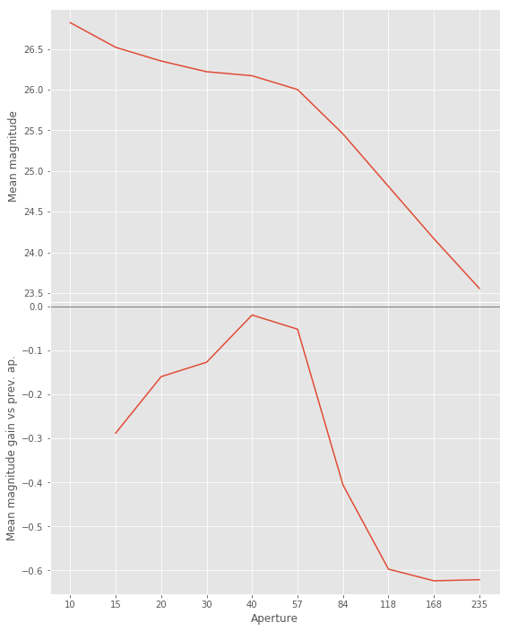

```python
nb_plot_mag_ap_evol(magnitudes['r'], stellarities['r'], labels=apertures)
```

We will use aperture 40 as target.

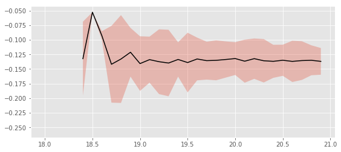

```python
nb_plot_mag_vs_apcor(orig_hsc['rmag_aperture20'], orig_hsc['rmag_aperture40'], stellarities['r'])
```

We use magnitudes between 19.0 and 20.5.

```python
# Aperture correction
mag_corr['r'], num, std = aperture_correction(
    orig_hsc['rmag_aperture20'], orig_hsc['rmag_aperture40'],
    stellarities['r'],
    mag_min=19.0, mag_max=20.5)
print("Aperture correction for r band:")
print("Correction: {}".format(mag_corr['r']))
print("Number of source used: {}".format(num))
print("RMS: {}".format(std))
```

```
Aperture correction for r band:
Correction: -0.1352062225341797
Number of source used: 1132
RMS: 0.03414906800433681
```

### I.c - i band

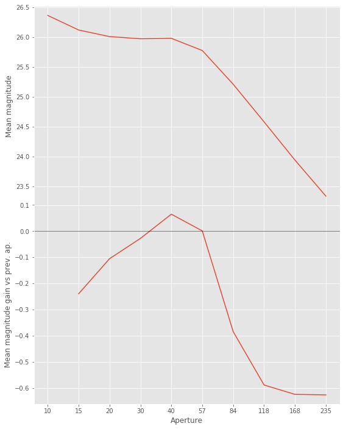

```python
nb_plot_mag_ap_evol(magnitudes['i'], stellarities['i'], labels=apertures)
```

We will use aperture 40 as target.

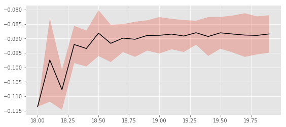

```python
nb_plot_mag_vs_apcor(orig_hsc['imag_aperture20'], orig_hsc['imag_aperture40'], stellarities['i'])
```

We use magnitudes between 18.5 and 19.8.

```python
# Aperture correction
mag_corr['i'], num, std = aperture_correction(
    orig_hsc['imag_aperture20'], orig_hsc['imag_aperture40'],
    stellarities['i'],
    mag_min=18.5, mag_max=19.8)
print("Aperture correction for i band:")
print("Correction: {}".format(mag_corr['i']))
print("Number of source used: {}".format(num))
print("RMS: {}".format(std))
```

```
Aperture correction for i band:
Correction: -0.08892059326171875
Number of source used: 1474
RMS: 0.005790887515601094
```

### I.d - z band

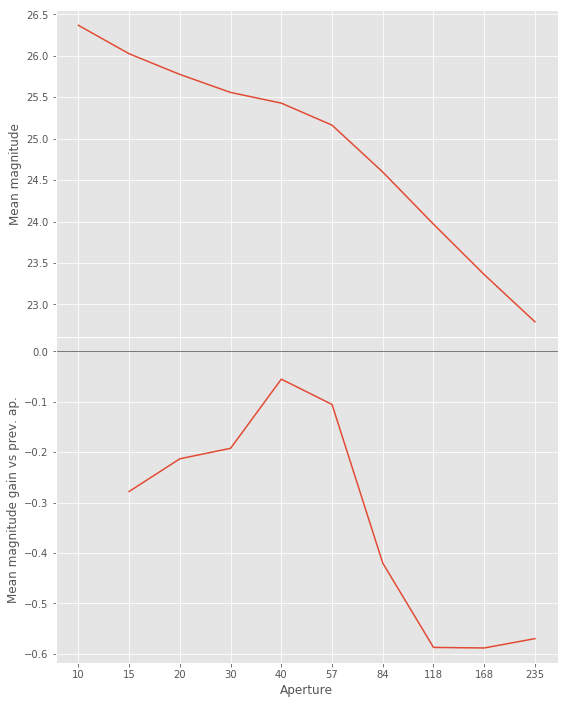

```python
nb_plot_mag_ap_evol(magnitudes['z'], stellarities['z'], labels=apertures)
```

We will use aperture 40 as target.

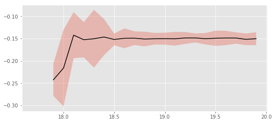

```python
nb_plot_mag_vs_apcor(orig_hsc['zmag_aperture20'], orig_hsc['zmag_aperture40'], stellarities['z'])
```

We use magnitudes between 18.5 and 19.8.

```python
# Aperture correction
mag_corr['z'], num, std = aperture_correction(
    orig_hsc['zmag_aperture20'], orig_hsc['zmag_aperture40'],
    stellarities['z'],
    mag_min=18.5, mag_max=19.8)
print("Aperture correction for z band:")
print("Correction: {}".format(mag_corr['z']))
print("Number of source used: {}".format(num))
print("RMS: {}".format(std))
```

```
Aperture correction for z band:
Correction: -0.14960098266601562
Number of source used: 1770
RMS: 0.013925026504311305
```

### I.e - y band

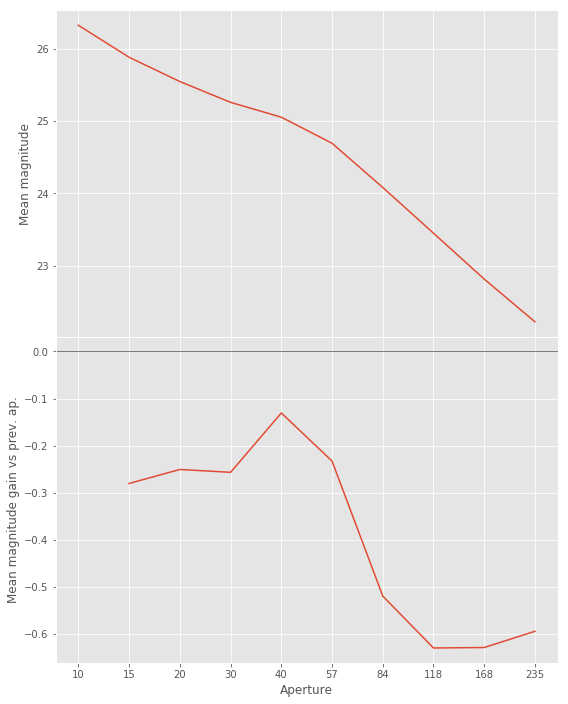

```python
nb_plot_mag_ap_evol(magnitudes['y'], stellarities['y'], labels=apertures)
```

We will use aperture 40 as target.

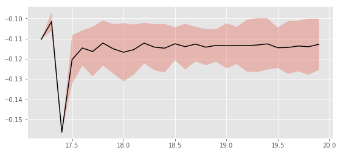

```python
nb_plot_mag_vs_apcor(orig_hsc['ymag_aperture20'], orig_hsc['ymag_aperture40'], stellarities['y'])
```

We use magnitudes between 18.0 and 19.5.

```python
# Aperture correction
mag_corr['y'], num, std = aperture_correction(
    orig_hsc['ymag_aperture20'], orig_hsc['ymag_aperture40'],
    stellarities['y'],
    mag_min=18.0, mag_max=19.5)
print("Aperture correction for y band:")
print("Correction: {}".format(mag_corr['y']))
print("Number of source used: {}".format(num))
print("RMS: {}".format(std))
```

```
Aperture correction for y band:
Correction: -0.11351203918457031
Number of source used: 1913
RMS: 0.010453534442076362
```

### I.f - n921 band

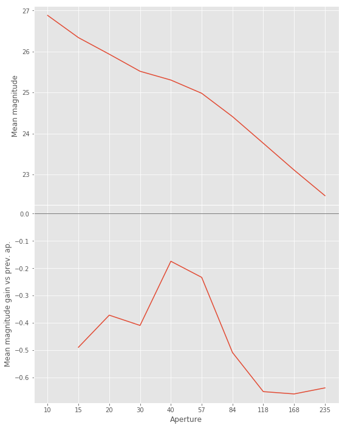

```python
nb_plot_mag_ap_evol(magnitudes['n921'], stellarities['n921'], labels=apertures)
```

We will use aperture 40 as target.

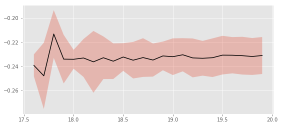

```python
nb_plot_mag_vs_apcor(orig_hsc['n921mag_aperture20'], orig_hsc['n921mag_aperture40'], stellarities['n921'])
```

We use magnitudes between 18.0 and 19.5.

```python
# Aperture correction
mag_corr['n921'], num, std = aperture_correction(
    orig_hsc['n921mag_aperture20'], orig_hsc['n921mag_aperture40'],
    stellarities['n921'],
    mag_min=18.0, mag_max=19.5)
print("Aperture correction for n921 band:")
print("Correction: {}".format(mag_corr['n921']))
print("Number of source used: {}".format(num))
print("RMS: {}".format(std))
```

```
Aperture correction for n921 band:
Correction: -0.23302078247070312
Number of source used: 1549
RMS: 0.014689342783144942
```

### I.g - n816 band

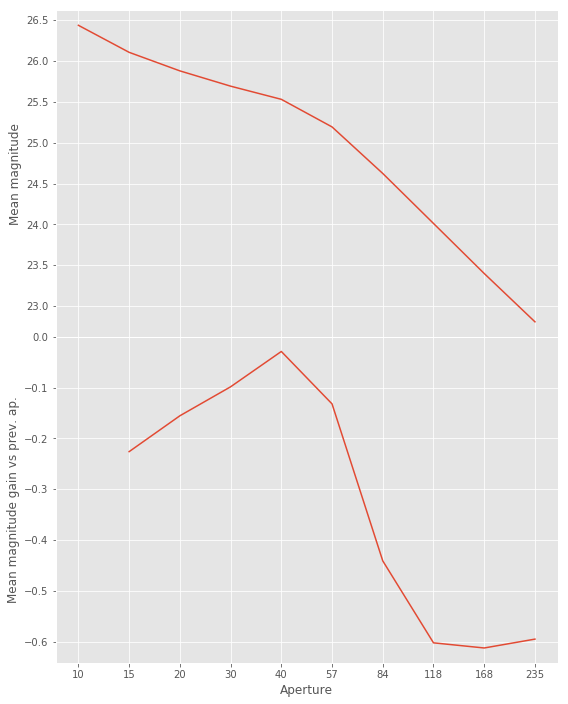

```python
nb_plot_mag_ap_evol(magnitudes['n816'], stellarities['n816'], labels=apertures)
```

We will use aperture 40 as target.

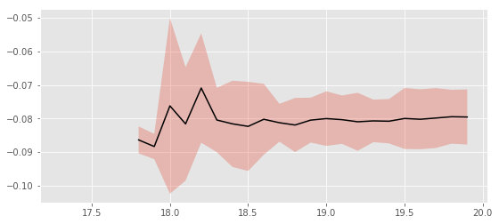

```python
nb_plot_mag_vs_apcor(orig_hsc['n816mag_aperture20'], orig_hsc['n816mag_aperture40'], stellarities['n816'])
```

We use magnitudes between 18.0 and 19.5.

```python
# Aperture correction
mag_corr['n816'], num, std = aperture_correction(
    orig_hsc['n816mag_aperture20'], orig_hsc['n816mag_aperture40'],
    stellarities['n816'],
    mag_min=18.0, mag_max=19.5)
print("Aperture correction for n816 band:")
print("Correction: {}".format(mag_corr['y']))
print("Number of source used: {}".format(num))
print("RMS: {}".format(std))
```

[output not shown]

## II - Stellarity

HSC does not provide a 0 to 1 stellarity value but a 0/1 extended flag in each band. We are using the same method as UKIDSS ([cf this page](http://wsa.roe.ac.uk/www/gloss_p.html#dxssource_pstar)) to compute a stellarity based on the class in each band:

\begin{equation*} P(star) = \frac{ \prod_{i} P(star)_i }{ \prod_{i} P(star)_i + \prod_{i} P(galaxy)_i } \end{equation*}

where $i$ is the band, and with using the same probabilities as UKDISS:

| HSC flag | UKIDSS flag | Meaning | P(star) | P(galaxy) | P(noise) | P(saturated) |
| --- | --- | --- | --- | --- | --- | --- |
|  | -9 | Saturated | 0.0 | 0.0 | 5.0 | 95.0 |
|  | -3 | Probable galaxy | 25.0 | 70.0 | 5.0 | 0.0 |
|  | -2 | Probable star | 70.0 | 25.0 | 5.0 | 0.0 |
| 0 | -1 | Star | 90.0 | 5.0 | 5.0 | 0.0 |
|  | 0 | Noise | 5.0 | 5.0 | 90.0 | 0.0 |
| 1 | +1 | Galaxy | 5.0 | 90.0 | 5.0 | 0.0 |

```python
# We are creating an array containing the extended flag in all band.
# Some sources have no flag in some band, there will be NaN in the array.
hsc_ext_flag = np.array([
    orig_hsc[colname] for colname in
    ['gclassification_extendedness',
     'rclassification_extendedness',
     'iclassification_extendedness',
     'zclassification_extendedness',
     'yclassification_extendedness',
     'n921classification_extendedness',
     'n816classification_extendedness']
])
```

```python
hsc_pstar = 0.9 * (hsc_ext_flag == 0) + 0.05 * (hsc_ext_flag == 1)
hsc_pgal = 0.05 * (hsc_ext_flag == 0) + 0.9 * (hsc_ext_flag == 1)

# We put back the NaN values
hsc_pstar[np.isnan(hsc_ext_flag)] = np.nan
hsc_pgal[np.isnan(hsc_ext_flag)] = np.nan
```

```python
stellarity = np.nanprod(hsc_pstar, axis=0) / np.nansum(
    [np.nanprod(hsc_pgal, axis=0), np.nanprod(hsc_pstar, axis=0)], axis=0)

stellarity = np.round(stellarity, 3)
```

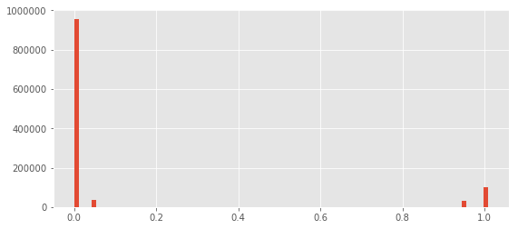

```python
vis.hist(stellarity, bins='scott');
```

```python
orig_hsc.add_column(Column(data=stellarity, name="stellarity"))
```

## II - Column selection

```python
imported_columns = OrderedDict({
        "object_id": "hsc-udeep_id",
        "ra": "hsc-udeep_ra",
        "dec": "hsc-udeep_dec",
        "gmag_aperture20": "m_ap_hsc-udeep_g",
        "gmag_aperture20_err": "merr_ap_hsc-udeep_g",
        "gmag_kron": "m_hsc-udeep_g",
        "gmag_kron_err": "merr_hsc-udeep_g",
        "rmag_aperture20": "m_ap_hsc-udeep_r",
        "rmag_aperture20_err": "merr_ap_hsc-udeep_r",
        "rmag_kron": "m_hsc-udeep_r",
        "rmag_kron_err": "merr_hsc-udeep_r",
        "imag_aperture20": "m_ap_hsc-udeep_i",
        "imag_aperture20_err": "merr_ap_hsc-udeep_i",
        "imag_kron": "m_hsc-udeep_i",
        "imag_kron_err": "merr_hsc-udeep_i",
        "zmag_aperture20": "m_ap_hsc-udeep_z",
        "zmag_aperture20_err": "merr_ap_hsc-udeep_z",
        "zmag_kron": "m_hsc-udeep_z",
        "zmag_kron_err": "merr_hsc-udeep_z",
        "ymag_aperture20": "m_ap_hsc-udeep_y",
        "ymag_aperture20_err": "merr_ap_hsc-udeep_y",
        "ymag_kron": "m_hsc-udeep_y",
        "ymag_kron_err": "merr_hsc-udeep_y",
        "n921mag_aperture20": "m_ap_hsc-udeep_n921",
        "n921mag_aperture20_err": "merr_ap_hsc-udeep_n921",
        "n921mag_kron": "m_hsc-udeep_n921",
        "n921mag_kron_err": "merr_hsc-udeep_n921",
        "n816mag_aperture20": "m_ap_hsc-udeep_n816",
        "n816mag_aperture20_err": "merr_ap_hsc-udeep_n816",
        "n816mag_kron": "m_hsc-udeep_n816",
        "n816mag_kron_err": "merr_hsc-udeep_n816",
        "stellarity": "hsc-udeep_stellarity"
    })


catalogue = orig_hsc[list(imported_columns)]
for column in imported_columns:
    catalogue[column].name = imported_columns[column]

epoch = 2017

# Clean table metadata
catalogue.meta = None
```

```python
# Aperture correction
for band in bands:
    catalogue["m_ap_hsc-udeep_{}".format(band)] += mag_corr[band]
```

```python
# Adding flux and band-flag columns
for col in catalogue.colnames:
    if col.startswith('m_'):

        errcol = "merr{}".format(col[1:])
        flux, error = mag_to_flux(np.array(catalogue[col]), np.array(catalogue[errcol]))

        # Fluxes are added in µJy
        catalogue.add_column(Column(flux * 1.e6, name="f{}".format(col[1:])))
        catalogue.add_column(Column(error * 1.e6, name="f{}".format(errcol[1:])))

        # Band-flag column
        if 'ap' not in col:
            catalogue.add_column(Column(np.zeros(len(catalogue), dtype=bool), name="flag{}".format(col[1:])))

# TODO: Set to True the flag columns for fluxes that should not be used for SED fitting.
```

```python
catalogue[:10].show_in_notebook()
```

<Table masked=True length=10>

| idx | hsc-udeep_id | hsc-udeep_ra | hsc-udeep_dec | m_ap_hsc-udeep_g | merr_ap_hsc-udeep_g | m_hsc-udeep_g | merr_hsc-udeep_g | m_ap_hsc-udeep_r | merr_ap_hsc-udeep_r | m_hsc-udeep_r | merr_hsc-udeep_r | m_ap_hsc-udeep_i | merr_ap_hsc-udeep_i | m_hsc-udeep_i | merr_hsc-udeep_i | m_ap_hsc-udeep_z | merr_ap_hsc-udeep_z | m_hsc-udeep_z | merr_hsc-udeep_z | m_ap_hsc-udeep_y | merr_ap_hsc-udeep_y | m_hsc-udeep_y | merr_hsc-udeep_y | m_ap_hsc-udeep_n921 | merr_ap_hsc-udeep_n921 | m_hsc-udeep_n921 | merr_hsc-udeep_n921 | m_ap_hsc-udeep_n816 | merr_ap_hsc-udeep_n816 | … |
| --- | --- | --- | --- | --- | --- | --- | --- | --- | --- | --- | --- | --- | --- | --- | --- | --- | --- | --- | --- | --- | --- | --- | --- | --- | --- | --- | --- | --- | --- | --- |
| 0 | 37484559004073991 | 34.8714549822 | -5.66512209621 | 28.1916 | 1.9237 | 27.9078 | 1.60423 | 27.4033 | 1.29248 | 27.1377 | 1.07784 | 23.8828 | 0.107892 | 23.8692 | 0.126365 | 23.3989 | 0.112058 | 23.5058 | 0.136464 | 23.2666 | 0.178543 | 23.2524 | 0.199698 | 26.3023 | 0.772093 | 26.1344 | 0.643872 | 27.0486 | 1.07229 | … |
| 1 | 37484559004073996 | 34.8829039964 | -5.66274638522 | 28.1952 | 1.93067 | 27.5233 | 1.34579 | 27.4383 | 1.33509 | 26.7849 | 0.930955 | 24.2424 | 0.152023 | 23.6781 | 0.125573 | 23.424 | 0.109132 | 23.3337 | 0.13363 | 22.8397 | 0.122972 | 22.6026 | 0.132162 | 26.3191 | 0.784305 | 25.7634 | 0.546897 | 27.067 | 1.09087 | … |
| 2 | 37484559004073997 | 34.8809825858 | -5.66260464633 | 28.1925 | 1.92531 | 26.8035 | 0.969285 | 27.4313 | 1.3261 | 26.0605 | 0.66772 | 24.0078 | 0.121362 | 23.602 | 0.162564 | 23.3866 | 0.108205 | 23.1722 | 0.162831 | 23.741 | 0.279326 | 25.568 | 2.81521 | 26.3151 | 0.781218 | 25.0421 | 0.393355 | 27.0624 | 1.08588 | … |
| 3 | 37484559004074001 | 34.8715190736 | -5.66145665793 | 28.1745 | 1.8935 | 29.081 | 2.71981 | 27.3939 | 1.28112 | 28.317 | 1.8377 | 24.5754 | 0.194619 | 24.6931 | 0.14557 | 25.4862 | 0.740247 | 25.4356 | 0.44854 | 24.8475 | 0.777421 | 25.7071 | 1.12809 | 26.2921 | 0.764794 | 27.3132 | 1.09729 | 27.0346 | 1.05839 | … |
| 4 | 37484559004074003 | 34.8829262475 | -5.66073303794 | 28.1874 | 1.91484 | 27.9063 | 1.5946 | 27.434 | 1.32845 | 27.1714 | 1.10673 | 24.0948 | 0.125606 | 24.024 | 0.140096 | 24.0722 | 0.199042 | 24.1215 | 0.229196 | 24.1686 | 0.41834 | 24.5851 | 0.694645 | 26.3148 | 0.780416 | 26.15 | 0.65015 | 27.0611 | 1.08383 | … |
| 5 | 37484559004074004 | 34.881142836 | -5.66051032504 | 28.1849 | 1.91116 | 28.2918 | 1.90059 | 27.4277 | 1.32125 | 27.5526 | 1.31386 | 24.7449 | 0.227218 | 24.7006 | 0.221924 | 25.1429 | 0.520915 | 24.9251 | 0.397348 | 25.3893 | 1.27908 | 24.8999 | 0.769317 | 26.3113 | 0.778179 | 26.534 | 0.77383 | 27.057 | 1.08011 | … |
| 6 | 37484559004074005 | 34.8890740619 | -5.6604107861 | 28.193 | 1.92659 | nan | nan | 27.4547 | 1.35541 | nan | nan | 25.5294 | 0.473055 | nan | nan | 24.4385 | 0.272794 | nan | nan | 24.0838 | 0.383556 | nan | nan | 26.3258 | 0.789146 | nan | nan | 27.0736 | 1.09749 | … |
| 7 | 37484559004074006 | 34.877236788 | -5.6603600368 | 28.1799 | 1.90192 | nan | nan | 27.414 | 1.30432 | nan | nan | 26.1137 | 0.79398 | nan | nan | 25.186 | 0.564613 | nan | nan | 24.6759 | 0.638943 | nan | nan | 26.3035 | 0.772453 | nan | nan | 27.0479 | 1.07088 | … |
| 8 | 37484559004074007 | 34.876108297 | -5.66030168658 | 28.1786 | 1.90141 | nan | nan | 27.4102 | 1.301 | nan | nan | 24.4991 | 0.183588 | nan | nan | 24.1887 | 0.221133 | nan | nan | 23.763 | 0.277792 | nan | nan | 26.3014 | 0.771697 | nan | nan | 27.0455 | 1.06948 | … |
| 9 | 37484559004074009 | 34.8825222407 | -5.6595355992 | 28.1827 | 1.90972 | 26.7957 | 0.970214 | 27.4304 | 1.32625 | 26.0615 | 0.673795 | 24.3539 | 0.166615 | 23.9706 | 0.228213 | 24.0648 | 0.206494 | 24.5041 | 0.562394 | 25.133 | 0.982368 | 24.9655 | 1.62279 | 26.3119 | 0.779596 | 25.0408 | 0.396069 | 27.0571 | 1.08161 | … |

## III - Removal of duplicated sources

We remove duplicated objects from the input catalogues.

```python
SORT_COLS = [
        'merr_ap_hsc-udeep_i', 'merr_ap_hsc-udeep_r', 'merr_ap_hsc-udeep_z',
        'merr_ap_hsc-udeep_y', 'merr_ap_hsc-udeep_g']
FLAG_NAME = 'hsc-udeep_flag_cleaned'

nb_orig_sources = len(catalogue)

catalogue = remove_duplicates(
    catalogue, RA_COL, DEC_COL,
    sort_col= SORT_COLS,
    flag_name=FLAG_NAME)

nb_sources = len(catalogue)

print("The initial catalogue had {} sources.".format(nb_orig_sources))
print("The cleaned catalogue has {} sources ({} removed).".format(nb_sources, nb_orig_sources - nb_sources))
print("The cleaned catalogue has {} sources flagged as having been cleaned".format(np.sum(catalogue[FLAG_NAME])))
```

```
The initial catalogue had 1128935 sources.
The cleaned catalogue has 1128841 sources (94 removed).
The cleaned catalogue has 79 sources flagged as having been cleaned
```

## III - Astrometry correction

We match the astrometry to the Gaia one. We limit the Gaia catalogue to sources with a g band flux between the 30th and the 70th percentile. Some quick tests show that this give the lower dispersion in the results.

```python
gaia = Table.read("../../dmu0/dmu0_GAIA/data/GAIA_XMM-LSS.fits")
gaia_coords = SkyCoord(gaia['ra'], gaia['dec'])
```

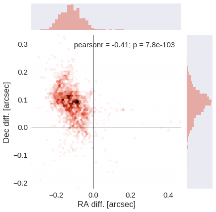

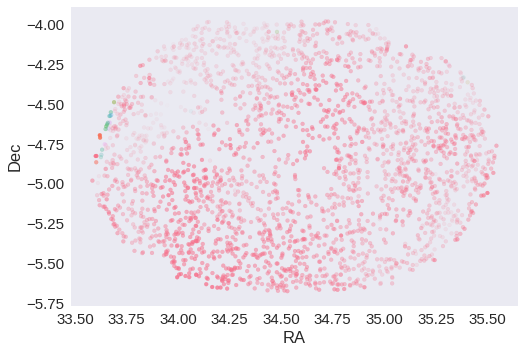

```python
nb_astcor_diag_plot(catalogue[RA_COL], catalogue[DEC_COL],
                    gaia_coords.ra, gaia_coords.dec)
```

```python
delta_ra, delta_dec =  astrometric_correction(
    SkyCoord(catalogue[RA_COL], catalogue[DEC_COL]),
    gaia_coords
)

print("RA correction: {}".format(delta_ra))
print("Dec correction: {}".format(delta_dec))
```

```
RA correction: 0.11995867840823848 arcsec
Dec correction: -0.08751257112411537 arcsec
```

```python
catalogue[RA_COL] +=  delta_ra.to(u.deg)
catalogue[DEC_COL] += delta_dec.to(u.deg)
```

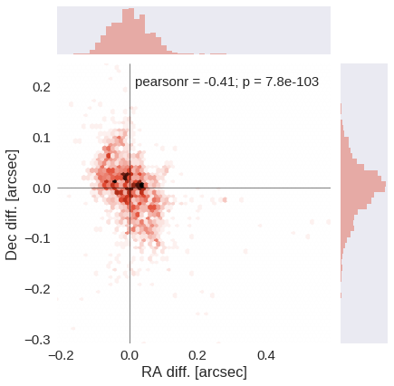

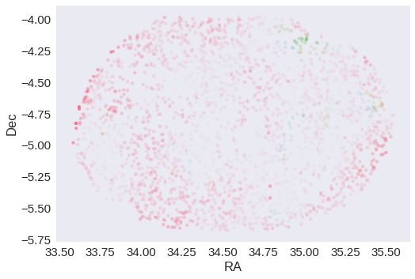

```python
nb_astcor_diag_plot(catalogue[RA_COL], catalogue[DEC_COL],
                    gaia_coords.ra, gaia_coords.dec)
```

## IV - Flagging Gaia objects

```python
catalogue.add_column(
    gaia_flag_column(SkyCoord(catalogue[RA_COL], catalogue[DEC_COL]), epoch, gaia)
)
```

```python
GAIA_FLAG_NAME = "hsc-udeep_flag_gaia"

catalogue['flag_gaia'].name = GAIA_FLAG_NAME
print("{} sources flagged.".format(np.sum(catalogue[GAIA_FLAG_NAME] > 0)))
```

```
2532 sources flagged.
```

# V - Saving to disk

```python
catalogue.write("{}/HSC-UDEEP.fits".format(OUT_DIR), overwrite=True)
```